# Relationship between global temperature and carbon emission

Angela Lin，Ningrui Yang，Yujia Zhai，Ruyi Liu

1/22/2022

### Report

#Code name: Climate Change

#Project title: Relationship between global temperature and carbon emission

#Authors: Angela Lin alin28@uw.edu Ruyi Liu rliu3@uw.edu Ningrui Yang yangning@uw.edu Yujia Zhai yzhai@uw.edu

#Affiliation: INFO-201: Technical Foundations of Informatics - The Information School - University of Washington

#Date: Winter 2022

#Abstract: Our main question is how the emission of CO2 influences the earth’s temperature. This question is important because environmental problems caused by climate change affect our daily life. Finally there will be more natural disasters. To address the question, we will make use of the dataset: Climate Change, and analyze how the temperature changed overtime.

#Keywords: Climate change, temperature, emission, development

#1.0 Introduction: Our project is to investigate the relationship between global temperature and carbon emission. We will use the data about carbon dioxide emission and average annual temperature to discuss the possible factors. We will analyze how industry development impacts carbon dioxide emissions and mainly focus on the differences between cities, countries, and U.S states. Also, we want to figure out if human activities are a critical element of climate change. In addition to the data analysis, we are going to design some questions and use the answers to build up a deeper understanding of this issue. This project can help us clarify how carbon dioxide affects global temperature, increase awareness of climate change, and demonstrate the solutions for decreasing global warming.

#2.0 Design Situation: -The concern of the topic is climate change, which is related to the environment study domain. The key elements in this topic are the emission of CO2, temperature change and global impact. The climate change topic is related to many aspects like: science, social, government and economics. Why the emission of CO2 will cause the temperature increase is a scientific question. When the climate changes our cultural and social situation will definitely alter. For example, when the temperature increases, the glacier will melt which will lead to floods and increase the sea level. When it comes to economic issues, industrial development was limited in order to alleviate climate change. The progress of the economy in many countries was restricted by environmental policy. - The human value of climate change is different for each person. Some people attach importance to it, but some others may hold the point that they do not care about it. Human values like: concerns of the lifetime of earth, environmental impact, and social development always be considered if people pay attention to climate change problems. “Based on this theory, Corner et al. (2014) concluded that self-transcendence values are expected to be strongly associated with positive engagement with climate change, while self-enhancing values appear less congruent with positive engagement with climate change.” - Direct stakeholders of climate change are people who live in the world. Climate change will cause more natural diseases like earthquakes and drought. People will be largely affected by these natural diseases. Besides, global warming will speed up the photochemical reaction between chemical pollutants in the atmosphere, causing harmful oxidants such as actinic aerosols to increase and induce some diseases. Such as eye inflammation, acute upper respiratory tract diseases, chronic bronchitis, emphysema, bronchial asthma and other diseases. Indirect stakeholders are industries. For example, global warming will seriously disrupt fisheries in some ways: carbon dioxide in the air causes ocean acidification, rising sea levels may change the ecology of fisheries, cold-water fish such as salmon may be deeply affected by warm currents, and the prospects for fisheries are very worrying. - As I mentioned earlier, climate change will cause more natural diseases, photochemical reactions, and ocean acidification. Besides, the sea level will rise. About ⅓ of the population of the world lives within 60 kilometers of the coastline, with a developed economy and urban density. These areas may be subject to inundation or intrusion, erosion of beaches and coasts. In the short term, farmers in some regions may benefit from the earlier onset of spring and from a longer warm season that is suitable for growing crops. Also, studies show that, up to a certain point, crops and other plants grow better in the presence of higher carbon dioxide levels and seem to be more drought-tolerant.

#3.0 Research questions: 1. Is climate change caused by humans? 2. How has global warming affected the world so far? 3. Will the actions we take today be enough to forestall the direct impacts of climate change? Or is it too little too late? The motivation of these questions is to ask people to think of the cause of climate change on the earth. When we look at the first question: Is climate change caused by humans, we have to reflect on our actions in the past. What did we do to bring harm to our environment? For the second one, we begin to consider the impact of climate change. Since we have the dataset with a great time span, we can definitely check the temperature change due to global warming. The last one is the future impact. We already know that people’s activities are the major factor of climate change. Therefore, whether the actions we have taken are useful to address the environment problems is really important.

#4.0 The Dataset: We have found two credible datasets that are potentially useful to us. One is the global land temperature data which we obtained from Kaggle—an online community for data scientists. It contains the temperature data (by month) from 1750 to 2015. There are five sub-sheets—categorized by city, country, major cities, states (the United States), and global in general. All sheets have three columns in common—date, the average temperature in celsius, and the average temperature uncertainty in celsius (95% confidence interval). Global Land and Ocean-and-Land Temperatures (GlobalTemperatures.csv) data consist of 9 columns, including the three columns in common. The dataset as a whole includes roughly 10 million observations. The original data is put together by Berkley Earth, an independent non-profit organization focused on environmental data science, combined with 1.6 billion temperature reports from 16 pre-existing archives. Berkley Earth organized the data to raise public attention about global warming. The study was entirely transparent—the source data and the code are published online. The data was later repackaged on Kaggle to allow easier use. The description notes that “early data were collected by technicians using mercury thermometers; thus, variation in visit time may impact readings. In the 1980s, there was a move to electronic thermometers that are said to have a cooling bias.”(Berkeley Earth, 2017) The second dataset about the Carbon dioxide emissions by region from 1750 to 2020 consists of 4 columns—region name, region code, year, and annual carbon dioxide emissions measured in tonnes. Each observation is defined by the region and the year, and a total of 65853 observations are included. We obtained this data from Our World in Data—a project of the Global Change Data Lab, a non-profit organization based in the United Kingdom. It’s about “Research and data to make progress against the world’s largest problems”, and the goal is to “make the knowledge on the big problems accessible and understandable.” The original dataset was published by Global Carbon Budget—Global Carbon Project (2021), a project that updates every year and is maintained by scholars all over the world. The full reference can be found at [Global Carbon Project](https://doi.org/10.18160/gcp-2021). Our World in Data only extracted territorial emissions from the original dataset—includes emissions from fossil fuel combustion and oxidation and cement production—which do not account for emissions embedded in traded goods and do not include the ‘Statistical differences’ column.

#5.0 Expected Implications: Through our research, people are able to be aware of the importance of preventing global warming and we need to take actions to help the world. In fact, people are now making a lot of changes to eliminate the negative effects of global warming like electric cars. Electric cars will be more common all over the world, then the number of emissions will decrease. Besides, the technology of electric cars will be improved and the flaws like short battery life will be eliminated. Based on our data analysis, the government in different countries can make more specific policies about the number of gas emissions to effectively address the problem. For example, they need to know how much they can emit correctly for energy conservation and how much to invest on the development of environmentally friendly energy. Numbers need to be calculated to implement these policies.

#6.0 Limitations: There are several limitations to our project. For one, changing global temperature is a wide-ranging issue; it is hard for us to analyze all the possible factors, which can be greenhouse gases, changes in Earth’s orbit and rotation, volcanic activity, etc. Therefore, we will focus on one aspect that we are all interested in— carbon emission. For another, based on the complicated factors for climate change, the main result we conclude from the dataset might not be entirely suitable for the whole process of climate change. That is, there might be some exceptional situations that our conclusions can’t explain. In order to get neutral conclusions, we will try to analyze the data in a most objective way.

#Acknowledgements: We would like to thank our teaching assistant Akshita Gundavarapu for giving us suggestions on this topic.

#References: 30, R. C.N., Cho, R., Wingham, K., Ament, J., Andrea, Alex, Gary, & Leinberger, B. (2018, January 18). Six tough questions about climate change. State of the Planet. Retrieved February 3, 2022, from https://news.climate.columbia.edu/2015/11/30/six-tough-questions-about-climate-change/

Climate change: Frequently asked questions. The Nature Conservancy. (2018, December 9). Retrieved February 3, 2022, from https://www.nature.org/en-us/what-we-do/our-priorities/tackle-climate-change/climate-change-stories/climate-change-frequently-asked-questions/#humans

Plumer, B., Resnick, B., & Irfan, U. (2017, June 1). 9 questions about climate change you were too embarrassed to ask. Vox. Retrieved February 4, 2022, from https://www.vox.com/science-and-health/2017/6/1/15724164/9-questions-climate-change-too-embarrassed-to-ask

Prati, G., Pietrantoni, L., & Albanesi, C. (2017, July 25). Human values and beliefs and concern about climate change: A Bayesian longitudinal analysis - quality & quantity. SpringerLink. Retrieved February 4, 2022, from https://link.springer.com/article/10.1007/s11135-017-0538-z#:~:text=Based%20on%20this%20theory%2C%20Corner,positive%20engagement%20with%20climate%20change.

Berkley Earth. (2017, May 1). Climate change: Earth surface temperature data. Kaggle. Retrieved February 5, 2022, from https://www.kaggle.com/berkeleyearth/climate-change-earth-surface-temperature-data?select=GlobalLandTemperaturesByState.csv

Hannah Ritchie and Max Roser (2020) - “CO₂ and Greenhouse Gas Emissions”. Published online at OurWorldInData.org. Retrieved from: https://ourworldindata.org/co2-and-other-greenhouse-gas-emissions

### Summary information

This script shows several values that we analyzed from our data. We found that the global average temperature change from the 18th century to the 19th century is -0.1939273, from the 19th century to the 20th century is 0.6286067, and from the 20th century to the 21st century is 0.9043821. We also found that the average temperature of countries after 2000 is 19.51453, the entity with the highest CO2 emission is Asia, the city with the highest average temperature in the most recent year in the dataset is Umm Durman. The state with the highest average temperature in the 21st century is Puducherry, India.

```
## $`Global average temperature changes from 18th century to 19th century`
## [1] -0.1939273
##
## $`Global average temperature changes from 19th century to 20th century`
## [1] 0.6286067
##
## $`Global average temperature changes from 20th century to 21st century`
## [1] 0.9043821
##
## $`Average temperature of counties after 2000`
## [1] 19.51453
##
## $`Entity with highest CO2 emission`
## [1] "Asia"
##
## $`City with highest average temperature in the mosr recent year`
## [1] "Umm Durman"
##
## $`State with highest average temperature in 21th century`
## [1] "Puducherry, India"
```

### us average temperature and co2 emission from 1990 to 2010

```
## # A tibble: 21 x 3
##     Year ave_temp `CO2 emission`
##    <dbl>    <dbl>          <dbl>
##  1  2010     9.51     5675786435
##  2  2009     9.14     5478209686
##  3  2008     8.95     5914077766
##  4  2007     9.84     6131004158
##  5  2006     9.97     6051668046
##  6  2005     9.89     6134521473
##  7  2004     9.67     6114006880
##  8  2003     9.76     6011837495
##  9  2002     9.82     5946770566
## 10  2001     9.79     5904881595
## # ... with 11 more rows
```

### global temperature and emissions overview

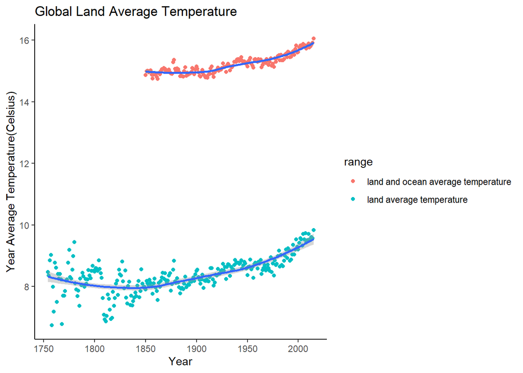

The purpose of this chart is to give an overview of changing of the global temperature from 1750 to 2015. each point represents the mean global temperature of the year. Some land average temperature data are missing before age 1754; thus, the observations before 1754 were removed. The ocean temperature data was not recorded until approximately 1850. The early land average temperature data were widely spread; however, the more recent data of both land and land-ocean data show a strong positive correlation with time. It may imply that the global temperature has been increasing over the past centuries.

### global CO2 emissions overview

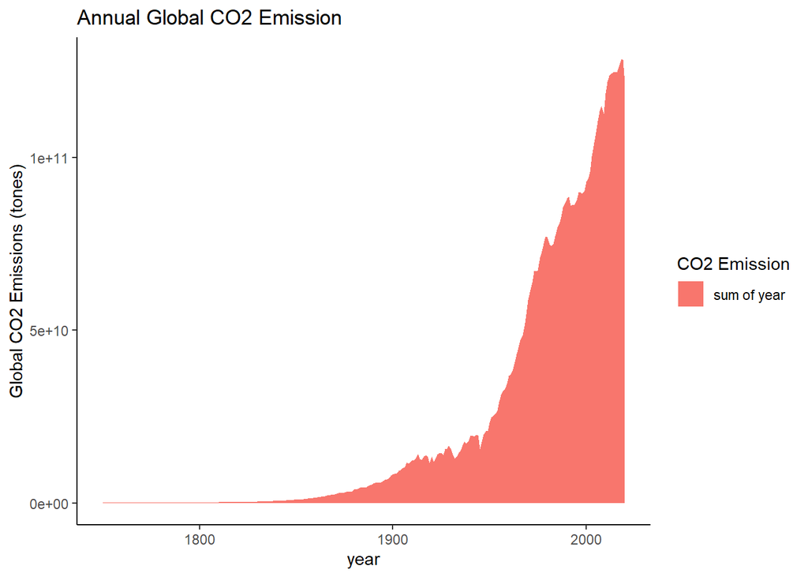

This chart shows the change in total global carbon dioxide emissions with respect to the year. This chart is intended to help answer the first research question, “is climate change caused by humans?” The chart shows a surge in global CO2 emission in the twentieth century.

### average temperature in the U.S overview

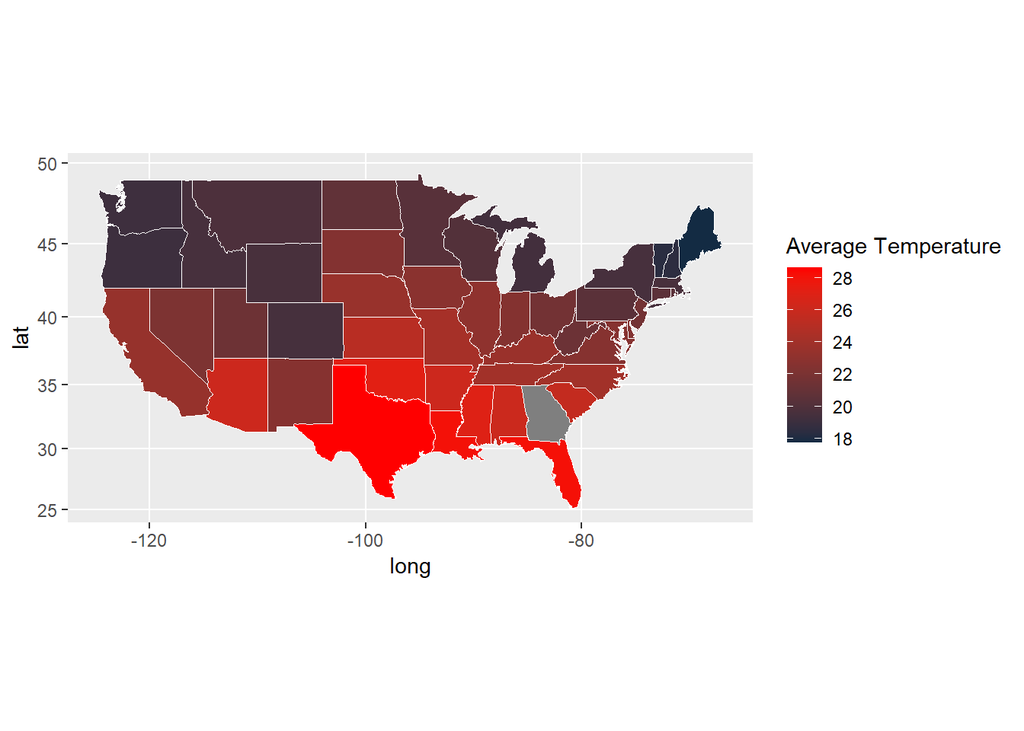

This is a choropleth map of average temperature of the U.S by state. This chart shows the difference of average temperature in each state of the U.S. This intend to help people have a overview about the average temperature in America and find the reason why different places will have different temperature like development or population.